# Introduction

1. technologies I used:
   - For database, I utilized ElasticSearch (ES), which is a distributed search engine, plus any NOSQL database (s3, mongoDB, or even local disk); ES is the key here, since it would allow you to search amd match historical records pretty quick.
2. matching algo
   - I would use the built-in tokenizor and also provide a list of common suffix for company name that will be removed as stop words.
   - will do if have more time: listed in the last part of this notebook.
3. FlowChart (shown below): 2 kinds of data generated and saved
   - The site record will be passed through the matching process and saved into elaticsearch database;
   - In the meantime, the metadata for matching reason will be generated and could be saved as well.
4. Accuracy
   - For my fake datasets, the accuracy is around 100% due I only test few cases. But in real life there is other scenarios need to be taken care of by updating the custom analyzer.
5. visualize parent-child relationships
   - When store the data, the parent and child relationship is also saved. I wrote a function to get children (sites) name with parent (organization) name; or vice versa.

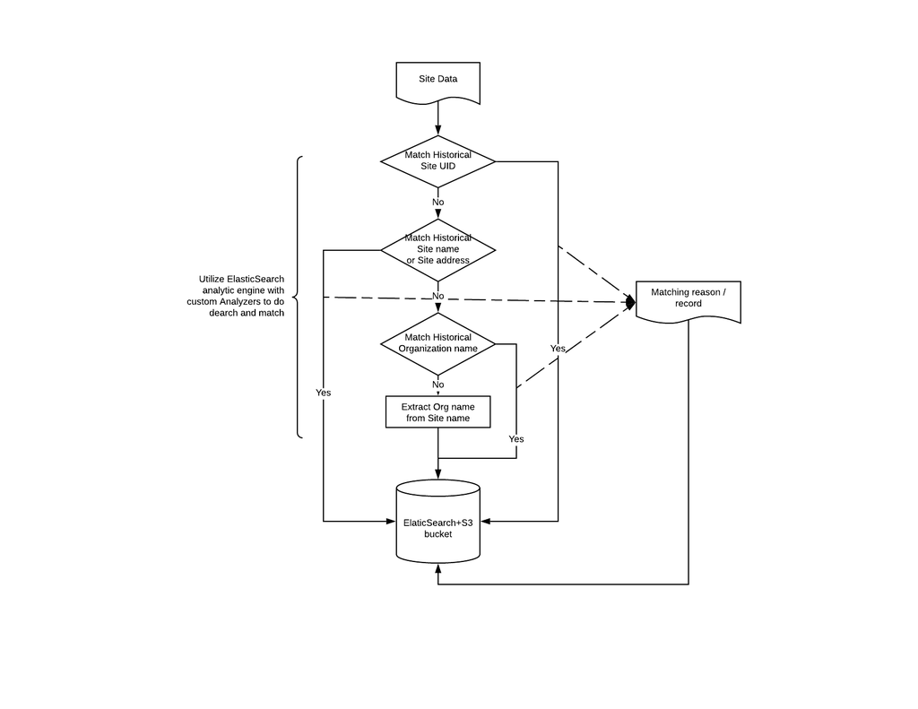

```python
from IPython.display import display, Image
# feature engineering pipeline
display(Image(filename='flowchart.png'))
```

# Prerequisites (run in command line)

```python
## have docker installed and run "docker compose up -d"
```

```python
## run "pip install -r requirements.txt"
```

# Import package and build ElasticSearch connection

```python
import elasticsearch
from pprint import pprint
# client using localhost:9200 and http requests transport
from elasticsearch.connection import RequestsHttpConnection
import pandas as pd
from elasticsearch.helpers import bulk
from pprint import pprint
from collections import defaultdict
from utils import *
import json
import plotly.express as px
from tqdm import tqdm
%reload_ext autoreload
%autoreload 2
```

```python
es = elasticsearch.Elasticsearch(sniff_on_start=True, connection_class=RequestsHttpConnection)
```

```python
elasticsearch.__version__
```

```
(7, 12, 1)
```

```python
# define some parameters
```

```python
INDEX_NAME = "org_sites"
TYPE_NAME = "_doc"
```

```python
if es.indices.exists(INDEX_NAME):
    es.indices.delete(INDEX_NAME)
```

```python
ORG_SUFFIX = ["Agency", "Gmbh", "PA", "and", "the", "of", "Group", "PC", "Assn", "Hotel", "Pharmacy", "Assoc", "Hotels", "PLC", "Associates", "Inc", "PLLC", "Association", "Incorporated", "Restaurant", "Bank", "International", "SA", "BV", "Intl", "Sales", "co", "Limited", "Service", "Comp", "LLC", "Services", "Company", "LLP", "Store", "Corp", "LP", "Svcs", "Corporation", "Ltd", "Travel", "DMD", "Manufacturing", "Unlimited", "Enterprises", "Mfg","research","lab","labarotary","warehouse"]
```

```python
ORG_SUFFIX = [o.lower() for o in ORG_SUFFIX]
```

# Read sample data and create "index"

1. I created fake organization and site data.
2. The "index" in elasticsearch world is like "database" in relational database
3. In the process of creating "index", I defined the data schema and also created a custom "analyzer" that is used to process the company and site name (will remove common used suffix)

## read sample data

```python
orgs = pd.read_excel('organizations.xlsx', sheet_name="orgs")
```

```python
sites = pd.read_excel('organizations.xlsx', sheet_name="sites")
```

```python
orgs.fillna("NULL",inplace=True)
sites.fillna("NULL",inplace=True)
```

## create index

```python
create_index(es,INDEX_NAME,ORG_SUFFIX)
```

```python
es.cluster.health(wait_for_status="yellow")
```

```
{'cluster_name': 'elastic-cookbook',
 'status': 'yellow',
 'timed_out': False,
 'number_of_nodes': 1,
 'number_of_data_nodes': 1,
 'active_primary_shards': 11,
 'active_shards': 11,
 'relocating_shards': 0,
 'initializing_shards': 0,
 'unassigned_shards': 6,
 'delayed_unassigned_shards': 0,
 'number_of_pending_tasks': 0,
 'number_of_in_flight_fetch': 0,
 'task_max_waiting_in_queue_millis': 0,
 'active_shards_percent_as_number': 64.70588235294117}
```

# Populate with organization data

I will population elasticsearch database with organization data first

```python
orgs_data = []
for i,r in orgs.iterrows():
    orgs_data.append({"_index":INDEX_NAME,"_id":str(r['_id']),\
                     "_source":{"org_name": r['name'], "org_address": r['address'],"join_field": {"name": "orgs"}}})
```

```python
bulk(es,orgs_data)
```

```
(4, [])
```

```python
results = es.search(index=INDEX_NAME,body={"query": {"match_all": {}}})
pprint(results)
```

```
{'_shards': {'failed': 0, 'skipped': 0, 'successful': 1, 'total': 1},
 'hits': {'hits': [{'_id': '1',
                    '_index': 'org_sites',
                    '_score': 1.0,
                    '_source': {'join_field': {'name': 'orgs'},
                                'org_address': '6800 Koll Center Pkwy Suite '
                                               '120, Pleasanton, CA 94566',
                                'org_name': 'Redica Systems'},
                    '_type': '_doc'},
                   {'_id': '2',
                    '_index': 'org_sites',
                    '_score': 1.0,
                    '_source': {'join_field': {'name': 'orgs'},
                                'org_address': '2000 Galloping Hill Road '
                                               'Kenilworth, NJ 07033 U.S.A',
                                'org_name': 'Merck&Co.'},
                    '_type': '_doc'},
                   {'_id': '3',
                    '_index': 'org_sites',
                    '_score': 1.0,
                    '_source': {'join_field': {'name': 'orgs'},
                                'org_address': 'One Amgen Center '
                                               'Drive,Thousand Oaks, CA '
                                               '91320-1799',
                                'org_name': 'Amgen'},
                    '_type': '_doc'},
                   {'_id': '4',
                    '_index': 'org_sites',
                    '_score': 1.0,
                    '_source': {'join_field': {'name': 'orgs'},
                                'org_address': 'NULL',
                                'org_name': 'Travis Co.'},
                    '_type': '_doc'}],
          'max_score': 1.0,
          'total': {'relation': 'eq', 'value': 4}},
 'timed_out': False,
 'took': 0}
```

# Classify and insert sites data

## the sites data need to be insert

```python
sites
```

|  | _id | uid | name | address |
| --- | --- | --- | --- | --- |
| 0 | 111 | 1111 | Merck Research Lab | 213 E Grand Ave, South San Farancisco, CA 94080 |
| 1 | 112 | 1112 | Merck | 1750 W Point Pike, Lansdale, PA 19446 |
| 2 | 113 | 1113 | Merck Animal Health Warehouse Building | 35500 W 91st St |
| 3 | 114 | 1114 | Amgen Building 13 Warehouse | 1 Amgen Center Dr, Thousand Oaks, CA 91320 |
| 4 | 115 | 1115 | Amgen | 12000 Plantside Dr, Louisville, KY 40299 |
| 5 | 116 | 1115 | Amgen Inc. | NULL |
| 6 | 117 | 1117 | Travis Building | Mohr Ave, Pleasanton, CA 94566 |
| 7 | 118 | 1118 | building | 1750 West Point Pike, PA 19446 |
| 8 | 119 | 1119 | Pfizer Manufacturing | 1200 Parkdale Rd, Rochester, MI 48307 |

## test custom analyzer (remove common company name suffix)

```python
an_body = {
    "analyzer":"name_stopwords",
     "text": "Pfizer Manufacturing"
}
es.indices.analyze(index=INDEX_NAME, body=an_body)
```

```
{'tokens': [{'token': 'pfizer',
   'start_offset': 0,
   'end_offset': 6,
   'type': '<ALPHANUM>',
   'position': 0}]}
```

## do the match and insert

```python
match_reason =[]
for i,row in tqdm(sites.iterrows()):
    res,_id = do_match(row,es,INDEX_NAME)
    # check if exists already
    q_ext = {
      "query": {
        "term": {
          "site_uid": _id
        }
      }
    }
    ext = do_search(es,INDEX_NAME,q_ext)
    while not ext['hits']['total']['value']:
        ext = do_search(es,INDEX_NAME,q_ext)
        continue
    match_reason.append(res)
```

```
9it [00:07,  1.13it/s]
```

```python
sites['reason']=match_reason
```

```python
sites
```

|  | _id | uid | name | address | reason |
| --- | --- | --- | --- | --- | --- |
| 0 | 111 | 1111 | Merck Research Lab | 213 E Grand Ave, South San Farancisco, CA 94080 | site_org_match with org _id: 2 |
| 1 | 112 | 1112 | Merck | 1750 W Point Pike, Lansdale, PA 19446 | site_org_match with org _id: 2 |
| 2 | 113 | 1113 | Merck Animal Health Warehouse Building | 35500 W 91st St | site_org_match with org _id: 2 |
| 3 | 114 | 1114 | Amgen Building 13 Warehouse | 1 Amgen Center Dr, Thousand Oaks, CA 91320 | site_org_match with org _id: 3 |
| 4 | 115 | 1115 | Amgen | 12000 Plantside Dr, Louisville, KY 40299 | site_org_match with org _id: 3 |
| 5 | 116 | 1115 | Amgen Inc. | NULL | historical_uid_match with _id: 115 |
| 6 | 117 | 1117 | Travis Building | Mohr Ave, Pleasanton, CA 94566 | site_org_match with org _id: 4 |
| 7 | 118 | 1118 | building | 1750 West Point Pike, PA 19446 | historical_name_address_match with _id: 112 |
| 8 | 119 | 1119 | Pfizer Manufacturing | 1200 Parkdale Rd, Rochester, MI 48307 | create new org-site with _id: 1191 |

```python
sites.to_csv("match_reason_for_sites.csv")
```

# Visualize parent-child

1. only show search children of the parent for now

```python
rr=p2child(es,INDEX_NAME,"Amgen")
```

```python
rr
```

```
{'parent': ['organization:Amgen'],
 'child': ['uid:1114,name:Amgen Building 13 Warehouse',
  'uid:1115,name:Amgen',
  'uid:1115,name:Amgen Inc.']}
```

```python
fig = px.treemap(
    names =  rr['child'],
    parents = rr['parent']*len(rr['child'])
)
fig.show()
```

[interactive chart not shown]

# Would have done if have more time

1. **pipeline building**: the whole process can be built and run with AWS.
2. **agree the different organization names**: some organizations will be represented by different name (like JPM and CHASE bank refer to the same org), if we have this issue, I will deal with that by either resort to third party model or self-train
3. **Address parsing**: for the address, I would use third party package like "usaddress" to parse the unstructured address strings into address component. Then it will increase the matching accuracy.
4. **New organization gleaned from site name**: Right now for the site with no parent, I just use the site name as the new created org name, which is not good. I will use package like "spacy" to extract ORG name from site name.
5. **Other features extracted from Site documents**: For my fake data, I didn't create other columns than what are mentioned by you. But in real world, I would also at least extract ORG names mentioned in the document or the website page of the sites, if have. This could help when the site name is totally different from the parent company name.